# Family planning knowledge and attitudes among women in Democratic Republic of Congo

Holy Andriamasy

2023-12-05

## 1. Introduction

The dataset used in this report is extracted from the 2018 Demographic Health Survey (DHS), a series of standardized survey conducted periodically at household and individual levels in different developing countries. This report describes women’s knowledge and attitudes towards family planning in Democratic Republic of Congo. The survey was answered by 18,827 women aged between 15 to 49 years-old. In regards with the topic of family planning, we will focus on women who are married/living with a partner in this report.

## 2. Description of basic demographics

Of all women, 78% have primary or secondary education, 64% live in rural areas, 23% are in the poorest wealth share and 66% are married or living with a partner. The majority of women with primary or no education live in rural areas whereas the majority of women with secondary of higher education live in urban areas (Figure 1). Likewise, the majority of women in the poorest and poorer wealth shares live in rural areas (Figure 2).

Finally, women in urban areas have on average 2.6 ever born children whereas women in rural areas have on average 3.5 ever born children, which is slightly higher than the number of ever born children by women in urban areas.

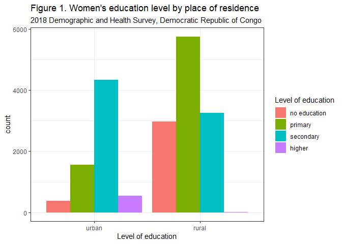

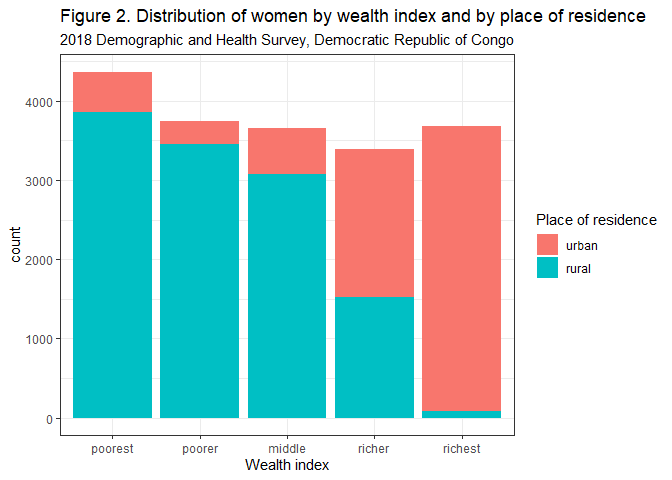

## 3. Knowledge on family planning

As we can see in Figure 3 below, whether in urban or rural areas, the majority of women who are married/living with a partner never heard about family planning in any of the main medias (radio, TV, newspaper/magazine).

Likewise, Figure 4 shows that the majority of women who visited a health facility for any reasons in the 12 months preceding the interview have not heard about family planning through any staff at the health facility in both urban and rural areas.

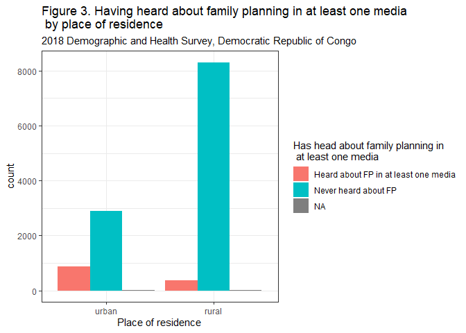

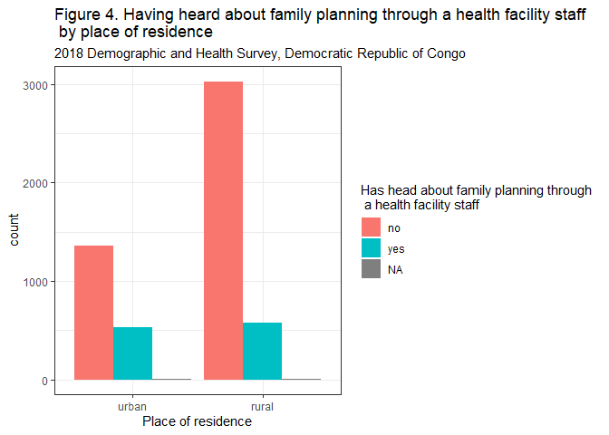

## 4. Attitudes towards the use of contraception

In this section, for comparison purposes, we will make the assumption that women from 40 year-old do not generally try to have new children and thus do not use contraception methods anymore. Hence, we will base our analysis on women aged under 40 year-old.

As we can see in Figures 5, 6 and 7 below, the majority of women aged under 40 years-old do not use any contraception methods regardless of the place of residence, wealth level or age group.

We can nonetheless see the following: a. More women in urban areas use modern contraception methods than in rural areas b. Women in rural areas tend to use traditional methods for contraception c. The richer the woman, the higher the probability to use modern contraception methods. d. Women in the highest wealth index share seem to more or less equally use traditional and modern methods. e. Women aged between 20 and 24 years-old tend to use modern methods more than younger women and those between 35 and 39 years-old.

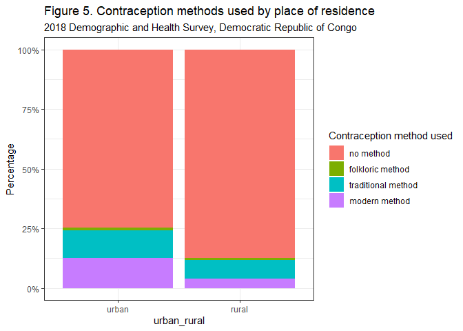

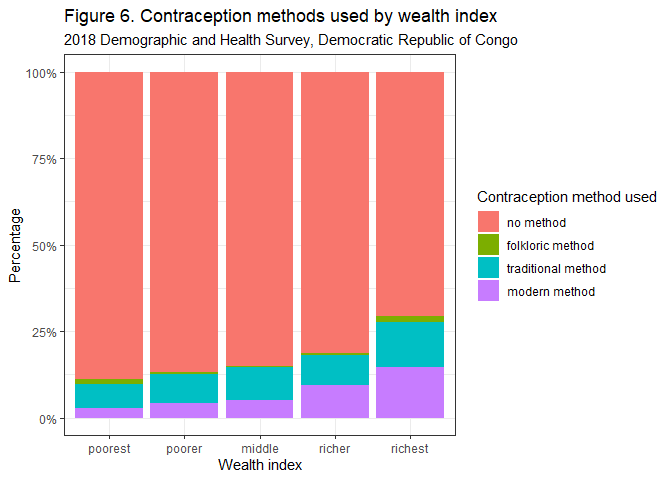

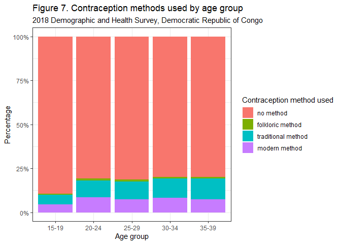

## 5. Reasons for not using contraception

We would like now to explore a few possible reasons leading to women not using contraception for family planning. To that end, we will select only women under 40 years-old who do not use any contraception methods.

The possible reasons chosen in our analysis are the following: - Husband is opposed to contraception - Contraception is prohibited by religion - The respondent does not know any contraception methods - Lack of access to contraception - Contraception costs too much

We will assume here that these reasons are linked to family planning and use the positive answers of each of the 5 reasons to make comparisons.

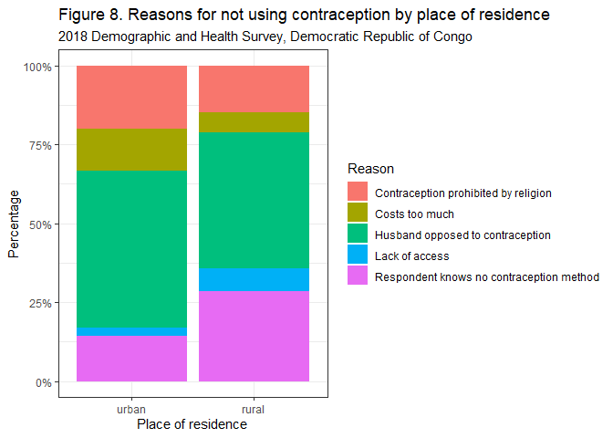

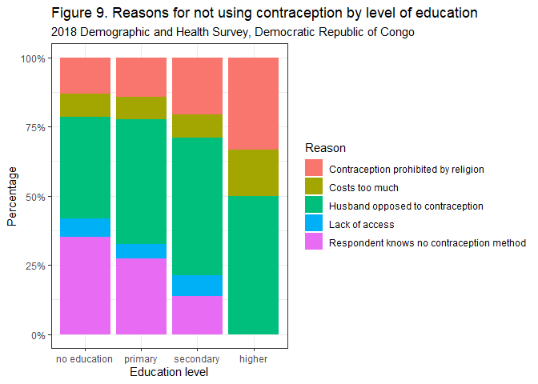

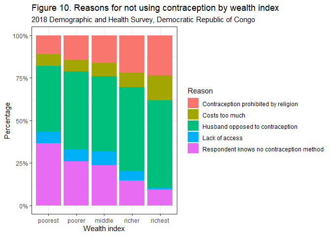

## 6. Conclusion

In summary, the majority of women in this survey have never heard about family planning. Especially for those living in rural areas, those with no education and the poorest ones, this finding is confirmed by the fact that women do not use contraception because they do not know any contraception methods. It also seems that the husband’s opinion is an important element in the decision of using contraception. For women using contraception, there is a more or less equal use of traditional and modern methods in the urban areas and in the richest part of wealth index.